# GGPLO2 - The First Contact

## 1.2 Weight of chicks on different diets

```r
# have a look at what the data looks like
head(chickwts)
```

```
##   weight      feed
## 1    179 horsebean
## 2    160 horsebean
## 3    136 horsebean
## 4    227 horsebean
## 5    217 horsebean
## 6    168 horsebean
```

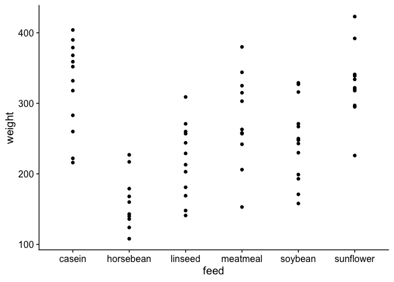

```r
# simple plot
ggplot(data=chickwts) +
  geom_point(mapping=aes(x=feed, y=weight))
```

As some of the points are hidden by others and the real distribution might be hard to see, you might want to plot this as a boxplot:

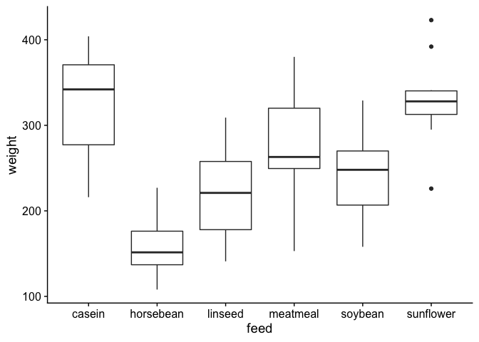

```r
ggplot(chickwts) +
  geom_boxplot(aes(x=feed, y=weight))
```

# 2 Subsetting your data and adding dimensions

We can also use ggplot to subset our data to make analysis easier. To do this, we expand the instructions of the mapping, that is, what characteristics of the plot (colour, alpha, size, shape) is mapped to which data.

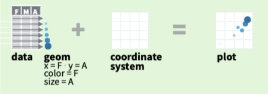

For this we will use another example of chicken weights, but with more information.

```r
head(ChickWeight)
```

```
##   weight Time Chick Diet
## 1     42    0     1    1
## 2     51    2     1    1
## 3     59    4     1    1
## 4     64    6     1    1
## 5     76    8     1    1
## 6     93   10     1    1
```

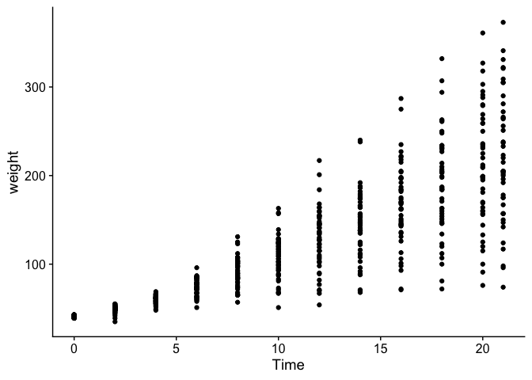

```r
ggplot(ChickWeight) +
  geom_point(aes(x=Time, y=weight))
```

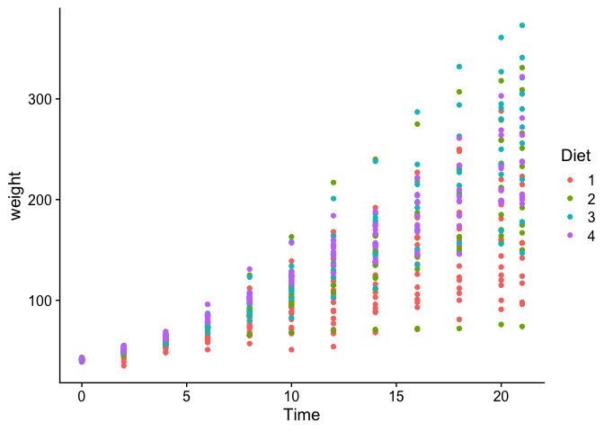

```r
# Colour by diet
ggplot(ChickWeight) +
  geom_point(aes(x=Time, y=weight, colour=Diet))
```

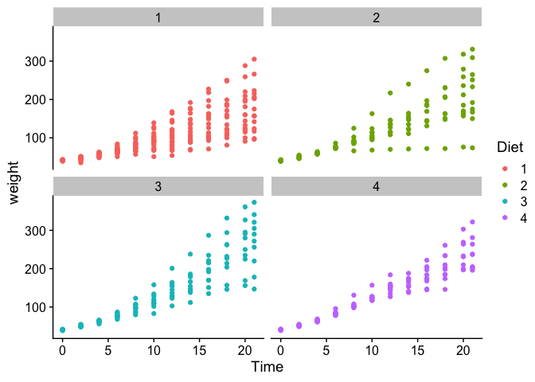

```r
# Facet by diet
ggplot(ChickWeight) +
  geom_point(aes(x=Time, y=weight, colour=Diet)) +
  facet_wrap("Diet")
```

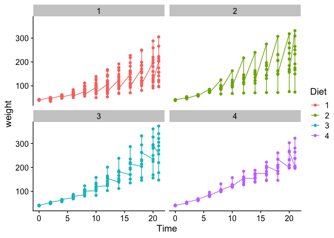

```r
# Add lines
ggplot(ChickWeight) +
  geom_point(aes(x=Time, y=weight, colour=Diet)) +
  geom_line(aes(x=Time, y=weight, colour=Diet)) +
  facet_wrap("Diet")
```

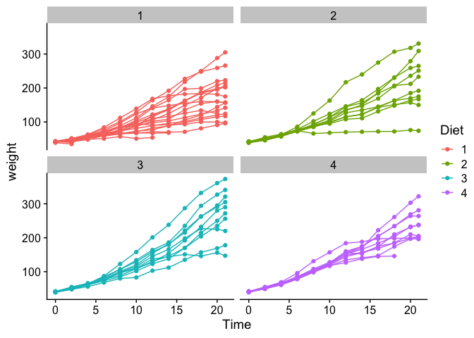

```r
# Add grouping
ggplot(ChickWeight) +
  geom_point(aes(x=Time, y=weight, colour=Diet)) +
  geom_line(aes(x=Time, y=weight, colour=Diet, group=Chick)) +
  facet_wrap("Diet")
```

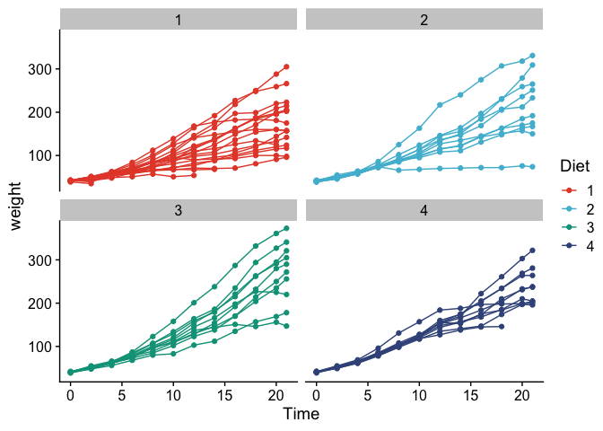

```r
# Use different colour scheme
library(ggsci)
  ggplot(ChickWeight) +
    geom_point(aes(x=Time, y=weight, colour=Diet)) +
    geom_line(aes(x=Time, y=weight, colour=Diet, group=Chick)) +
    facet_wrap("Diet") +
    scale_color_npg()
```

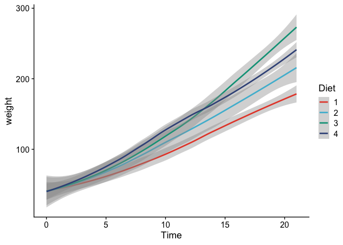

```r
  ggplot(ChickWeight) +
    # geom_point(aes(x=Time, y=weight, colour=Diet)) +
    stat_smooth(aes(x=Time, y=weight, colour=Diet)) +
    # facet_wrap("Diet", nrow=1) +
    scale_color_npg()
```

# 3 Reusing your code

Another great feature of `ggplot` is that you can re-use the same code for different variables in your data set, without having to write the code for the same style of figure over and over again. For that, let’s have a look at some flowers:

```r
head(iris)
```

```
##   Sepal.Length Sepal.Width Petal.Length Petal.Width Species
## 1          5.1         3.5          1.4         0.2  setosa
## 2          4.9         3.0          1.4         0.2  setosa
## 3          4.7         3.2          1.3         0.2  setosa
## 4          4.6         3.1          1.5         0.2  setosa
## 5          5.0         3.6          1.4         0.2  setosa
## 6          5.4         3.9          1.7         0.4  setosa
```

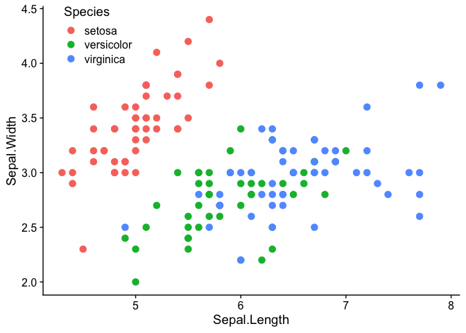

```r
ggplot(iris) +
  geom_point(aes(x=Sepal.Length, y=Sepal.Width, colour=Species), size=3) +
  theme(legend.position=c(.05,.9))
```

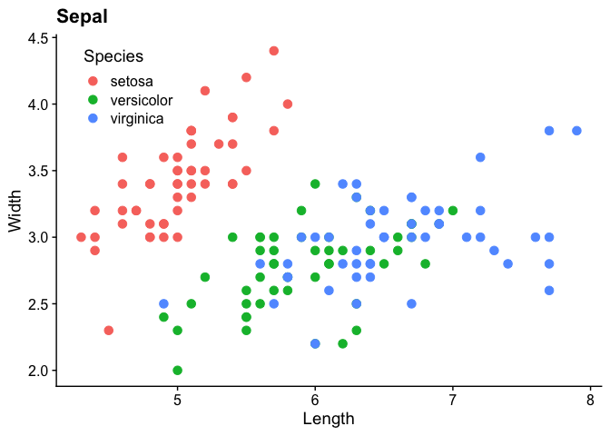

```r
## Which is identical to:
p <- ggplot(iris, aes(colour=Species)) +
  xlab("Length") +
  ylab("Width") +
  theme(legend.position=c(.05,.85))
p + geom_point(aes(x=Sepal.Length, y=Sepal.Width), size=3) + ggtitle("Sepal")
```

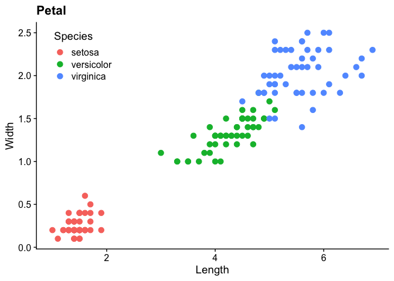

```r
## And so we can write for Petal
p + geom_point(aes(x=Petal.Length, y=Petal.Width), size=3) + ggtitle("Petal")
```

# 4 Combining plots

It is often useful to combine several plots into a single figure. A package that is especially useful to do this is the `cowplot` package. Let us have a look how to use it:

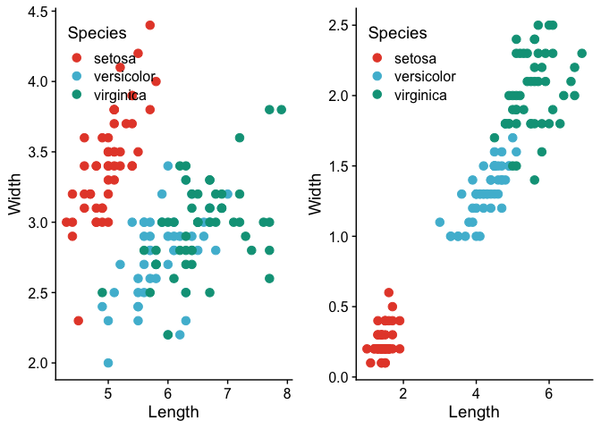

```r
p <- p + scale_color_npg()
sepalPlot <- p + geom_point(aes(x=Sepal.Length, y=Sepal.Width), size=3)
petalPlot <- p + geom_point(aes(x=Petal.Length, y=Petal.Width), size=3)

plot_grid(sepalPlot, petalPlot)
```

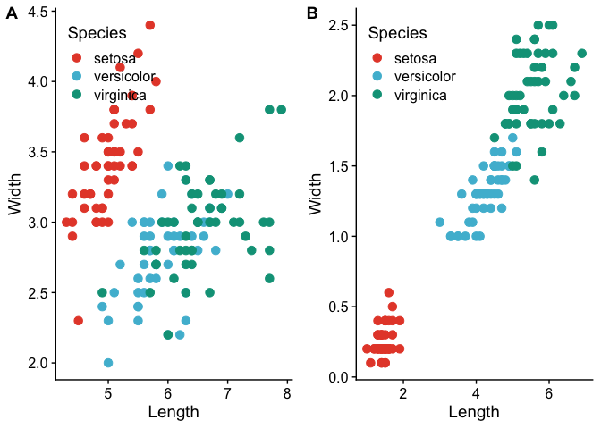

```r
plot_grid(sepalPlot, petalPlot, labels="AUTO")
```

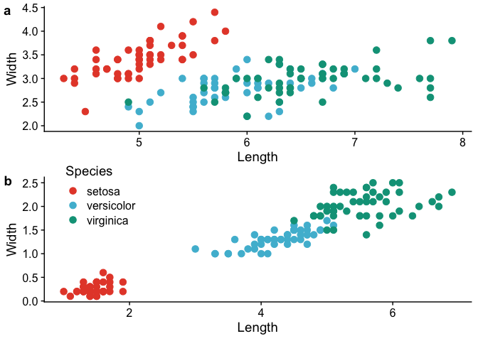

```r
plot_grid(sepalPlot+theme(legend.position=""), petalPlot, labels="auto", ncol=1)
```

Another very useful function `cowplot` provides is the save function, which lets you easily save a figures as a PNG or PDF:

```r
save_plot(
  plot_grid(sepalPlot, petalPlot, labels="auto", ncol=1),
  filename="~/Desktop/flower_area.pdf", base_height=8, base_width=8
)
```

# 5 Calculations within a ggplot call

Let’s calculate the sepal and petal area:

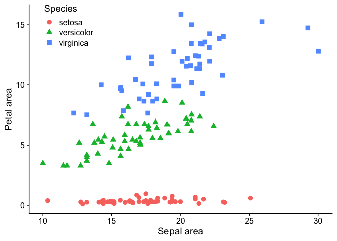

```r
ggplot(iris) +
  geom_point(aes(x=Sepal.Length*Sepal.Width,
                 y=Petal.Length*Petal.Width,
                 colour=Species,
                 shape=Species), size=3) +
  xlab("Sepal area") +
  ylab("Petal area") +
  theme(legend.position=c(.05,.9))
```

# 6 Adding lines and regressions

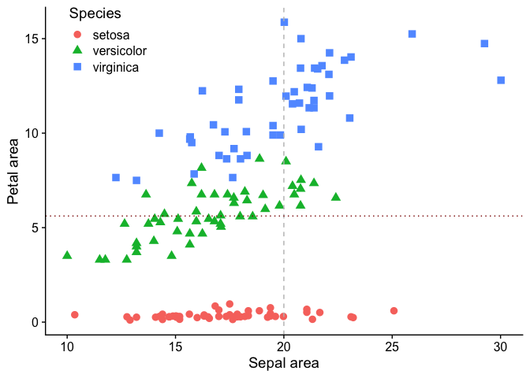

```r
ggplot(iris, aes(x=Sepal.Length*Sepal.Width, y=Petal.Length*Petal.Width, colour=Species, shape=Species)) +
  geom_point(size=3) +
  geom_vline(xintercept=20, linetype=2, colour="grey") +
  geom_hline(aes(yintercept=median(Petal.Length*Petal.Width)), linetype=3, colour="darkred") +
  xlab("Sepal area") +
  ylab("Petal area") +
  theme(legend.position=c(.05,.9))
```

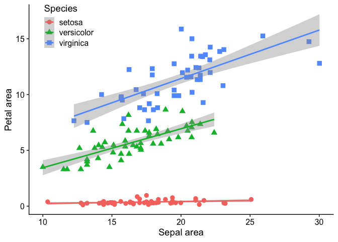

```r
ggplot(iris, aes(x=Sepal.Length*Sepal.Width, y=Petal.Length*Petal.Width, colour=Species, shape=Species)) +
  geom_point(size=3) +
  geom_smooth(method="lm") +
  xlab("Sepal area") +
  ylab("Petal area") +
  theme(legend.position=c(.05,.9))
```

# 7 Addinig regression from a linear model manually

```r
out <- lm(data=iris, formula= Petal.Width ~ Petal.Length)
out$coefficients[1]
```

```
## (Intercept)
##  -0.3630755
```

```r
out$coefficients[2]
```

```
## Petal.Length
##    0.4157554
```

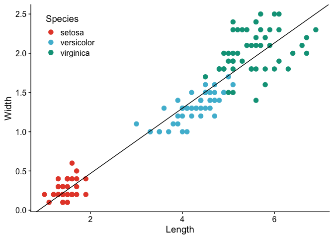

```r
petalPlot + geom_abline(intercept=out$coefficients[1], slope=out$coefficients[2])
```

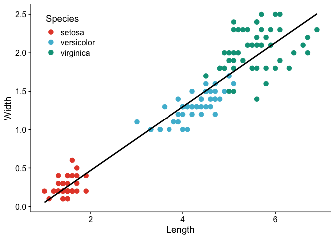

```r
# which is identical to:
petalPlot + stat_smooth(aes(x=Petal.Length, y=Petal.Width), col="black", method="lm", se=F)
```

# 8 Changing colour themes

Chanding up colours using the Brewer palettes

[output not shown]

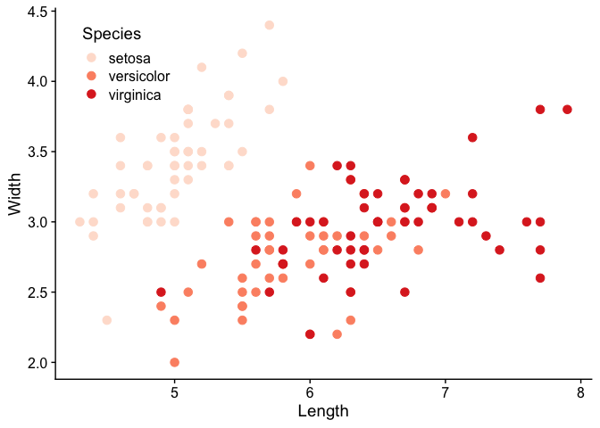

```r
sepalPlot + scale_color_brewer(palette="Reds")
```

For printing you sometimes need a grey scale:

[output not shown]

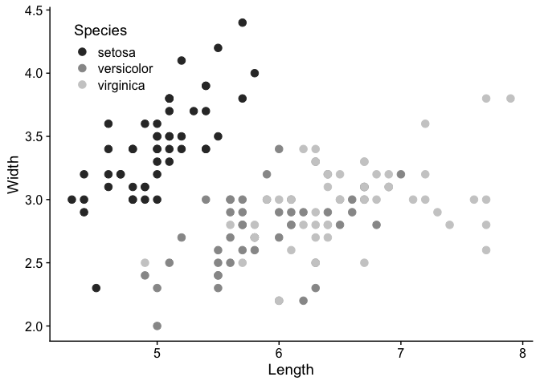

```r
sepalPlot + scale_color_grey()
```

# 9 Plotting your own data

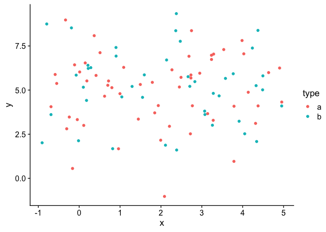

```r
df <- data.frame(x=runif(100, -1, 5),
           y=rnorm(100, 5, 2),
           type=sample(c("a","b"), 100, replace=T))

ggplot(df) + geom_point(aes(x=x, y=y, col=type))
```

# 10 More Resources

- [ggplot2 cheat sheets](https://github.com/rstudio/cheatsheets/blob/master/data-visualization-2.1.pdf)
- for better colour scales have a look at the `viridis` [package](https://cran.r-project.org/web/packages/viridis/vignettes/intro-to-viridis.html)
- More on `cowplot` see [the CRAN page](https://cran.r-project.org/web/packages/cowplot/vignettes/introduction.html) and another [example on github](https://github.com/marcosmolla/Cowplot_Publishable_Figures)
- To create documents like this have a look at RStudio’s [RMarkdown explainer](https://rmarkdown.rstudio.com/lesson-1.html)
- A gallery of [RMarkdown themes](http://www.datadreaming.org/post/r-markdown-theme-gallery/)
- This document uses the ‘leonids’ theme of the `prettydoc` package. For more information visit the [development page](http://github.com/yixuan/prettydoc/)